# In-Class Exercises: Distributions

XDASI 2021

Kris Gunsalus

9/20/2021

## Normal Distribution

Several relatively recent GWAS studies have determined that 80% of height is heritable, and that many loci contribute to height variation.

Load the dataset and take a look at it.

```r
data(father.son)
head(father.son)
```

```
##    fheight  sheight
## 1 65.04851 59.77827
## 2 63.25094 63.21404
## 3 64.95532 63.34242
## 4 65.75250 62.79238
## 5 61.13723 64.28113
## 6 63.02254 64.24221
```

### Histogram

Put the data in long form and make a histogram.

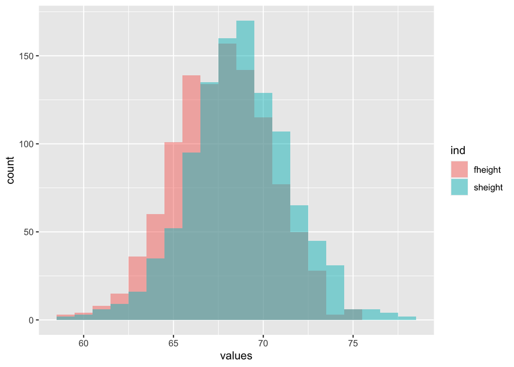

```r
fs.long = stack(father.son)

ggplot(data = fs.long, aes(x=values, fill=ind)) +
  geom_histogram(position="identity",
                 alpha = 0.5,
                 binwidth = 1)
```

## QQ Plot

Make a normal QQ plot of the full dataset. Do these data look approximately normally distributed?

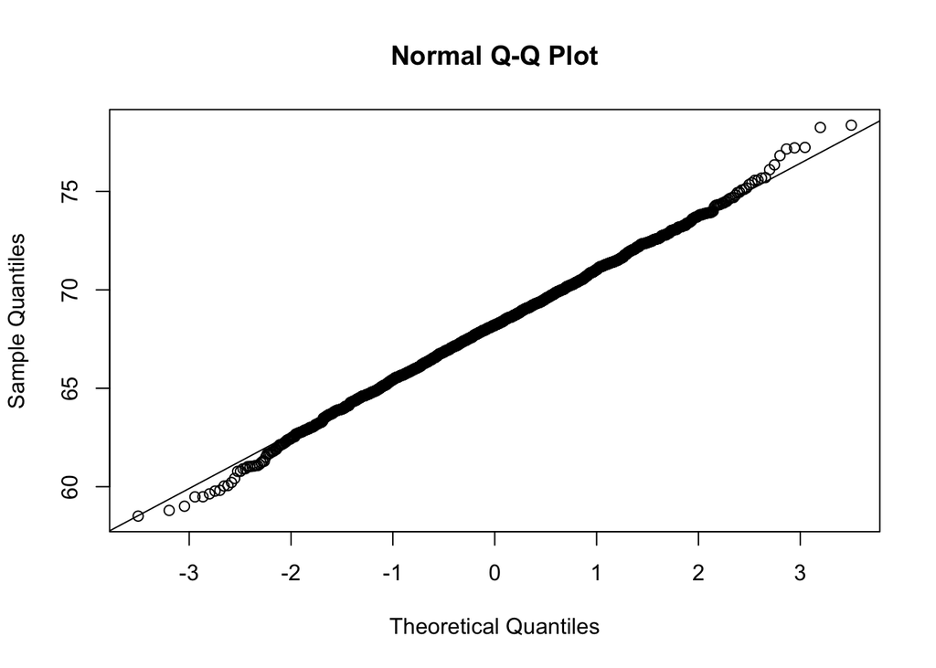

```r
# all
qqnorm(fs.long$values)
qqline(fs.long$values)
```

```r
# subsets
# f.height = fs.long[which(fs.long$ind == "fheight"),"values"]
# s.height = fs.long[which(fs.long$ind == "sheight"),"values"]
# qqnorm(f.height)
# qqline(f.height)
# qqnorm(s.height)
# qqline(s.height)
```

Take a look at the QQplot. What units are the quantiles in on the x- and y-axes? What do they represent?

## Random sampling

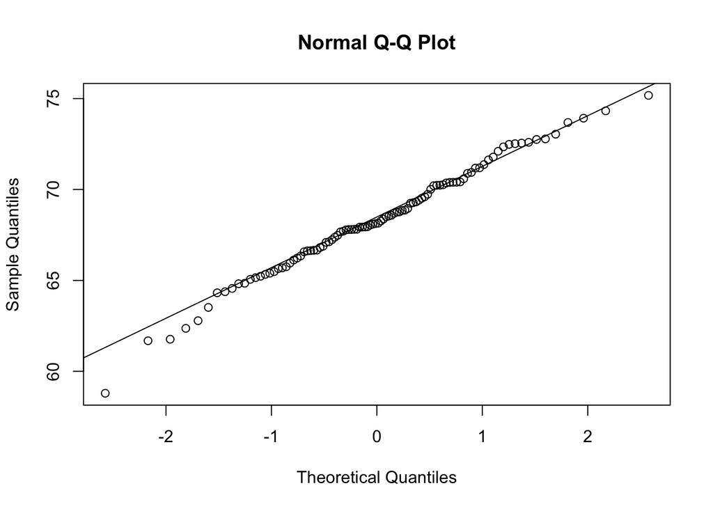

```r
f.sample = sample(fs.long$values, 100)
qqnorm(f.sample)
qqline(f.sample)
```

Sometimes we will want to resample from a finite dataset to simulate taking a bunch of random samples from a larger population. In such cases we often want to sample “with replacement” to get a more representative sample. Can you think of a reason why this could make a difference?

Try this out below, setting `replace=TRUE`. Do your results look much different here?

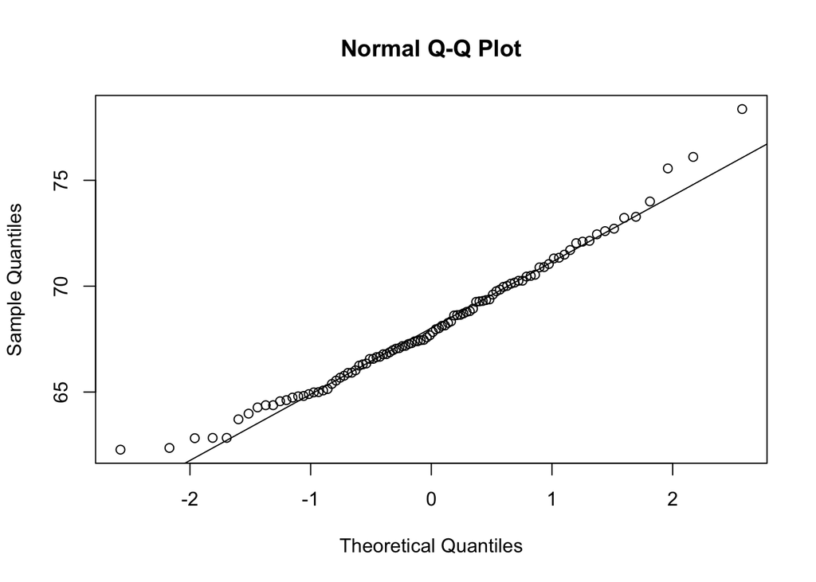

```r
f.sample = sample(fs.long$values, 100, replace=TRUE)
qqnorm(f.sample)
qqline(f.sample)
```

## Summary statistics

What are the mean and sd of the combined data?

```r
mean.fs = mean(fs.long$values)
sd.fs   = sd(fs.long$values)
c(mean.fs, sd.fs)
```

```
## [1] 68.185583  2.823728
```

## CDF and quantile functions

Use R’s dqpr functions to find the boundaries for the IQR of the combined data, based on an idealized normal distribution with the same mean and sd as the actual dataset.

```r
iqr.lower = qnorm(0.25, mean.fs, sd.fs)
iqr.upper = qnorm(0.75, mean.fs, sd.fs)
c(iqr.lower,iqr.upper)
```

```
## [1] 66.28101 70.09016
```

Assuming that the idealized distribution is a close approximation of the larger population, what proportion of men in the population are expected to be shorter than 65 inches?

```r
pnorm(65, mean.fs, sd.fs)
```

```
## [1] 0.1296287
```

What proportion of the men are expected to measure between over 75 inches?

```r
pnorm(75, mean.fs, sd.fs, lower.tail = FALSE)
```

```
## [1] 0.007905067
```

```r
1 - pnorm(75, mean.fs, sd.fs)
```

```
## [1] 0.007905067
```

What proportion of the men are expected to measure between 65 and 75 inches?

```r
pnorm(75, mean.fs, sd.fs) - pnorm(65, mean.fs, sd.fs)
```

```
## [1] 0.8624662
```

Do these sum to 100% of the total population?

```r
pnorm(65, mean.fs, sd.fs) +                                # under 65
  pnorm(75, mean.fs, sd.fs) - pnorm(65, mean.fs, sd.fs) +  # between 65-75
  pnorm(75, mean.fs, sd.fs, lower.tail = FALSE)            # over 75
```

```
## [1] 1
```

What height corresponds to the lowest 10% of heights? The highest 10%?

```r
qnorm(0.1, mean.fs, sd.fs)
```

```
## [1] 64.56683
```

```r
qnorm(0.9, mean.fs, sd.fs)
```

```
## [1] 71.80434
```

## ECDF

R contains a function to compute an **empirical CDF (ECDF)** called `ecdf()`. Use this to plot the ECDF for this dataset.

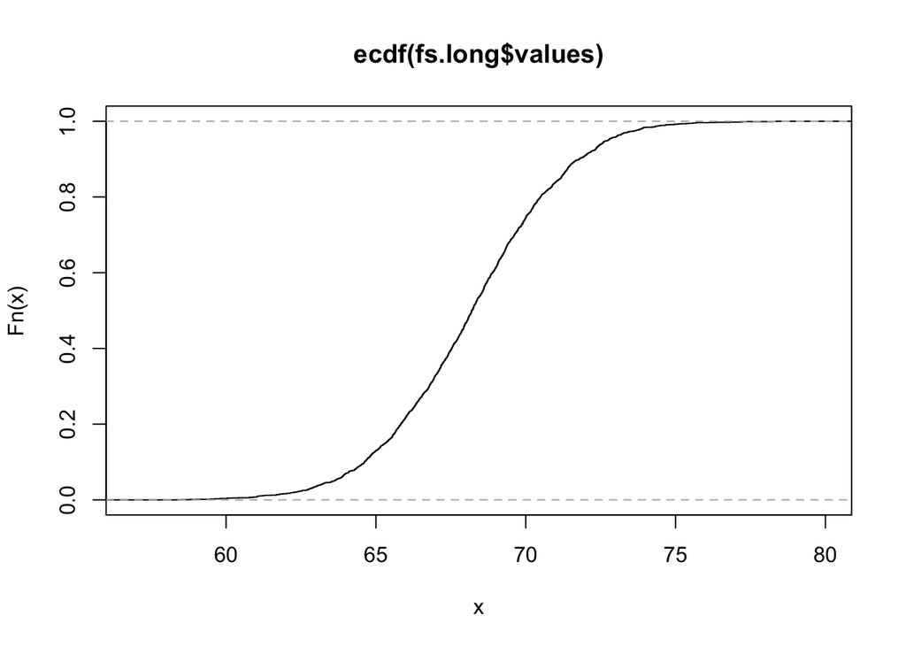

```r
fs.ecdf = ecdf(fs.long$values)
plot(fs.ecdf)
```

```r
summary(fs.ecdf)
```

```
## Empirical CDF:     2153 unique values with summary
##    Min. 1st Qu.  Median    Mean 3rd Qu.    Max.
##   58.51   66.32   68.20   68.18   70.02   78.36
```

```r
# what is it?
class(fs.ecdf)  # a function!
```

```
## [1] "ecdf"     "stepfun"  "function"
```

```r
quantile(fs.ecdf)
```

```
##       0%      25%      50%      75%     100%
## 58.50708 66.31346 68.19702 70.02889 78.36479
```

```r
quantile(fs.ecdf)[3]  # 50% quantile
```

```
##      50%
## 68.19702
```

```r
# proportion below a certain value
fs.ecdf(c(60,65,70,75))
```

```
## [1] 0.003710575 0.129406308 0.744434137 0.992115028
```

```r
fs.ecdf(mean(fs.long$values))  # what should this be?
```

```
## [1] 0.4967532
```

# Simulation

It’s often useful to simulate data to explore possibilities. Let’s do this below for some normally distributed data.

```r
# set a seed
set.seed(9-18-1963)

# simulate a standard normal distribution
n = 100
z = rnorm(n, mean=0, sd=1)  # take 100 samples from std normal (with replacement!)
mean(z)                     # check
```

```
## [1] -0.02739443
```

```r
var(z)
```

```
## [1] 0.7666996
```

Let’s compare the ECDF and the theoretical ECDF.

```r
x = seq(-3, 3, length = n)
ecdf.z.fun = ecdf(z)

class(ecdf.z.fun)  # it's a function
```

```
## [1] "ecdf"     "stepfun"  "function"
```

```r
ecdf.z.fun(0)  # what should this be?
```

```
## [1] 0.52
```

Now let’s plot it:

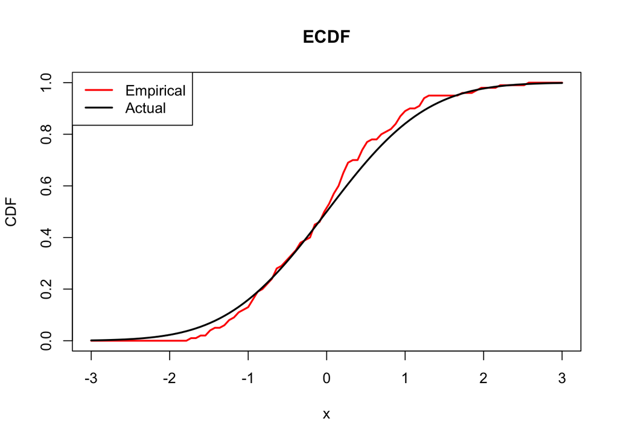

```r
# We can plot it
plot(x, ecdf.z.fun(x), lwd=2, col="red", type="l", ylab="CDF", main="ECDF")
lines(x, pnorm(x), lwd=2)
legend("topleft", legend=c("Empirical", "Actual"), lwd=2,
       col=c("red","black"))
```

We can do something similar with the PDF:

```r
# make a histogram object, but don't plot it
hist.obj = hist(z, breaks=30, plot=FALSE)
class(hist.obj) # a list
```

```
## [1] "histogram"
```

```r
hist.obj$breaks    # breakpoints used
```

```
##  [1] -1.8 -1.6 -1.4 -1.2 -1.0 -0.8 -0.6 -0.4 -0.2  0.0  0.2  0.4  0.6  0.8  1.0
## [16]  1.2  1.4  1.6  1.8  2.0  2.2  2.4  2.6
```

```r
hist.obj$density   # estimated probabilities
```

```
##  [1] 0.10 0.15 0.20 0.20 0.35 0.45 0.30 0.30 0.55 0.65 0.25 0.40 0.15 0.40 0.10
## [16] 0.20 0.00 0.05 0.10 0.05 0.00 0.05
```

Now we can make the plot with the ideal distribution overlaid:

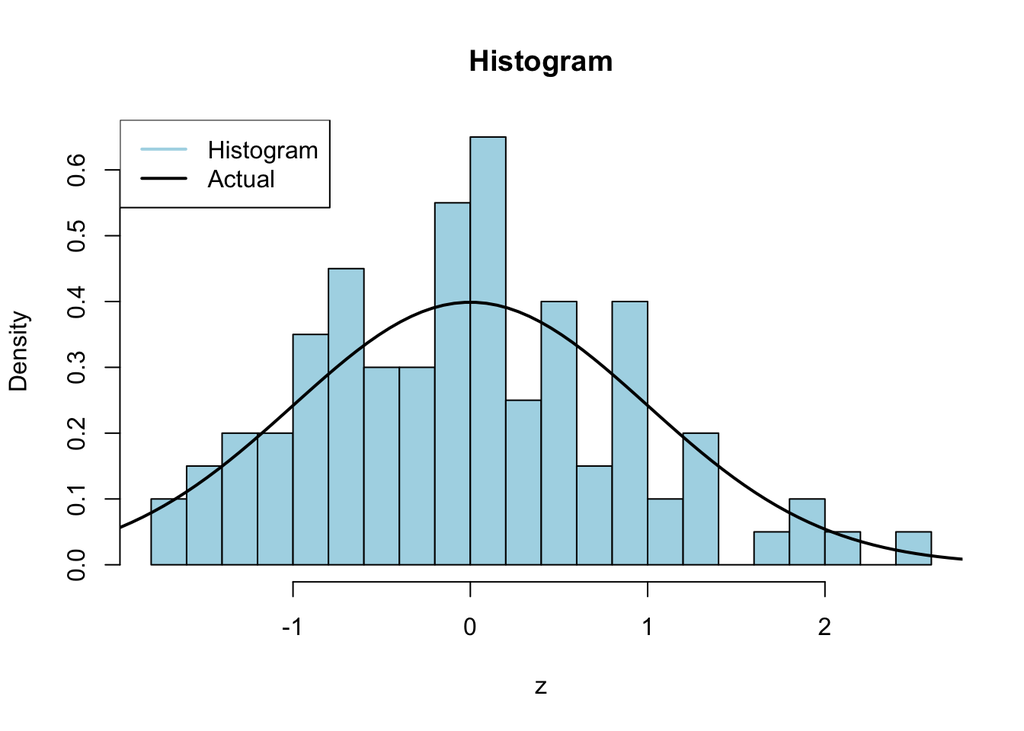

```r
# We can plot it
plot(hist.obj, col="lightblue", freq=FALSE, main="Histogram")
lines(x, dnorm(x), lwd=2)
legend("topleft", legend=c("Histogram", "Actual"), lwd=2,
       col=c("lightblue","black"))
```

## Setting seeds

Note that if you re-run this code several times with a new sample each time, the results can vary quite a bit. You can make your simulations come out the same every time using `set.seed(<some integer>)`. Try adding this before you generate your random sample and see what happens.

## Compare empirical height distributions with ideal distributions

Now that you’ve seen how to simulate a normally distributed sample and compare it to an ideal one, see if you can similar graphs using the height dataset at your own pace after class.